# asn4

```python
import pandas as pd
import numpy as np
from scipy.sparse import csr_matrix
from sklearn.ensemble import IsolationForest
from sklearn.preprocessing import StandardScaler
from sklearn.decomposition import TruncatedSVD
import matplotlib.pyplot as plt
from tqdm import tqdm
import time
from sklearn.metrics import f1_score
from itertools import product
```

## Importing data

```python
df = pd.read_csv("/Users/user/Documents/school/411_unsupervised_learning/mod10/assignment-4-option-1-training.csv")

df_te = pd.read_csv("/Users/user/Documents/school/411_unsupervised_learning/mod10/assignment-4-option-1-test.csv")
```

Given the size of the data sets, we decided the null frequencies were low enough that we could drop them.

```python
df.isnull().sum()/len(df)
```

```
ID       0.000000
Prod     0.000000
Quant    0.033493
Val      0.003858
Insp     0.000000
dtype: float64
```

```python
df_te.isnull().sum()/len(df_te)
```

```
ID       0.000000
Prod     0.000000
Quant    0.008899
Val      0.003115
Insp     0.000000
dtype: float64
```

```python
df = df.dropna()
df_te = df_te.dropna()
```

## EDA

Some basic questions about the data.

- What is the average sales rep performance (by `Quan` and `Val`)?
- What is the average total sales per product?
- What is the average sale price per product?
- How does that deviate from rep to rep?

#### Sales/Sales volume per rep, with log added for easier visualization.

```python
# avg quant/val per sales rep
sales_rep_avg = df.groupby("ID")[['Quant', 'Val']].mean()
```

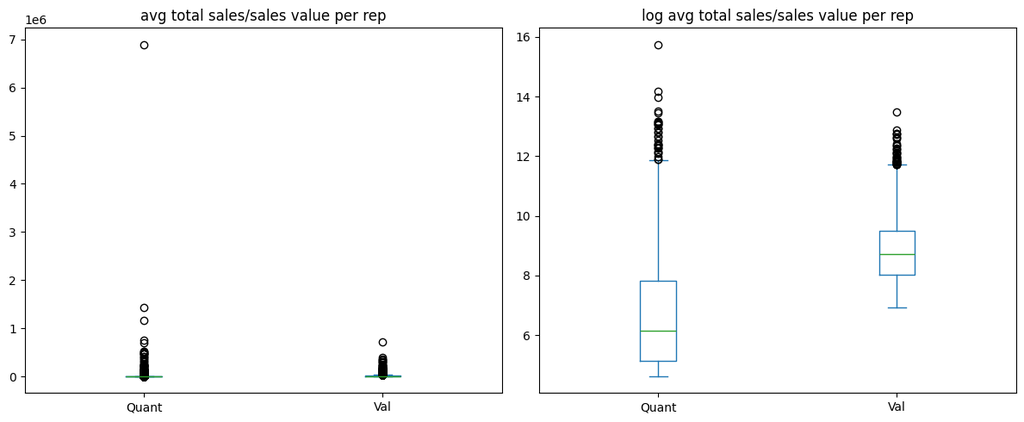

```python
fig, axes = plt.subplots(1, 2, figsize=(12, 5))
(sales_rep_avg).plot(kind="box", title="avg total sales/sales value per rep", ax=axes[0])

np.log1p(sales_rep_avg).plot(kind="box", title="log avg total sales/sales value per rep", ax=axes[1])

plt.tight_layout()
plt.show()
```

### Average quantity and value per product

Again, with logs added for easier viz.

```python
# avg quant/val per item
prod_avg = df.groupby("Prod")[['Quant', 'Val']].mean()
prod_avg['Each'] = prod_avg['Val'] / prod_avg['Quant']
```

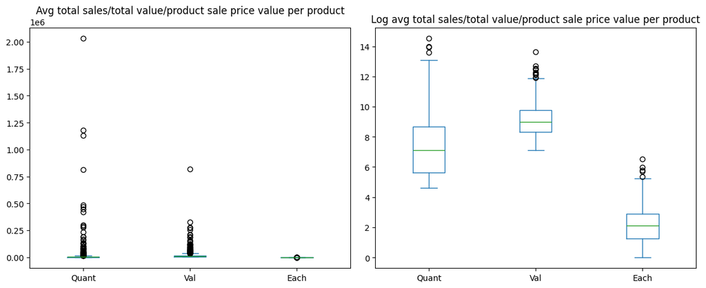

```python
fig, axes = plt.subplots(1, 2, figsize=(12, 5))
(prod_avg).plot(kind="box", title="Avg total sales/total value/product sale price value per product", ax=axes[0])

np.log1p(prod_avg).plot(kind="box", title="Log avg total sales/total value/product sale price value per product", ax=axes[1])

plt.tight_layout()
plt.show()
```

A quick dive into the distribution of differences and % differences. Mostly leaving this in here in case I need to reference it later.

```python
prod_rep_avg = df.groupby(["ID", 'Prod'])[['Quant', 'Val']].mean().reset_index().round(2)

prod_rep_avg['Each'] = prod_rep_avg.apply(
    lambda r: r['Val']/r['Quant'], axis=1
)

prod_rep_avg = prod_rep_avg.merge(prod_avg, on="Prod", how="left", suffixes=("", "_avg")).round(2)
```

```python
for c in ['Quant', 'Val', 'Each']:
    prod_rep_avg[c + "_diff"] = prod_rep_avg[c] - prod_rep_avg[c + "_avg"]
    prod_rep_avg[c + "_pct_diff"] = (prod_rep_avg[c + "_diff"]/prod_rep_avg[c + "_avg"])*100
```

```python
prod_rep_avg[[c for c in prod_rep_avg if c.endswith("pct_diff")]].round().describe().round(2)
```

|  | Quant_pct_diff | Val_pct_diff | Each_pct_diff |
| --- | --- | --- | --- |
| count | 26064.00 | 26064.00 | 26064.00 |
| mean | -10.81 | -12.95 | 47.99 |
| std | 139.86 | 119.52 | 537.94 |
| min | -100.00 | -100.00 | -96.00 |
| 25% | -71.00 | -70.00 | -26.00 |
| 50% | -38.00 | -42.00 | 1.00 |
| 75% | -4.00 | 7.00 | 48.00 |
| max | 5865.00 | 5996.00 | 40082.00 |

```python
df.head()
```

|  | ID | Prod | Quant | Val | Insp |
| --- | --- | --- | --- | --- | --- |
| 0 | v43 | p11 | 1032.0 | 4115.0 | unkn |
| 1 | v44 | p11 | 718.0 | 4780.0 | unkn |
| 2 | v45 | p11 | 585.0 | 3810.0 | unkn |
| 3 | v46 | p11 | 904.0 | 7310.0 | unkn |
| 4 | v42 | p11 | 6989.0 | 35850.0 | unkn |

## Feature Engineering

We have a lot of data, mostly categorical, and numerical features that appear to at least be reasonably distributed, so we opted to forego further cleaning and focus on better model tuning for now.

We did feel that the price of an individual item for each rep was an interesting data point, however, given that it is easily calculated by simple division, it felt inefficient to add that to the data. Instead, we opted for the difference between each sales rep's average price and the overall average price for a given product, which we called `Price_dev`.

```python
df['Each'] = df['Val'] / df['Quant']
df['Avg_Each'] = df.groupby('Prod')['Each'].transform('mean')
df['Price_dev'] = df['Each'] - df['Avg_Each']
```

Categorical variables need to be converted to "dummy" columns, one for each category. A large number of categorical variables (5080 `ID` + 797 `Prod`) means a lot of dummy variables.

```python
df.nunique()
```

```
ID            5080
Prod           797
Quant        11474
Val          11830
Insp             1
Each         67759
Avg_Each       797
Price_dev    99130
dtype: int64
```

Since most of these will be zeroes, we can use truncated SVD, a dimension reduction technique that works particularly well for sparse data.

```python
num_cols = ['Quant', 'Val', 'Price_dev']
extra_cols = ['Each', 'Avg_Each', 'Insp']

# scale the numeric features separately
X_num_scaled = StandardScaler().fit_transform(df[num_cols])

# create dummy variables
df_dummies = pd.get_dummies(df.drop(columns=num_cols+extra_cols), drop_first=True)

# convert to a sparse matrix for efficiency
X_sparse = csr_matrix(df_dummies.values)
```

Optimizing SVD means figuring out how many components you need to capture the majority of the variance in your data.

The plot of the number of components v. the cumulative captured variance is called a Scree Plot.

As you can see below, we are only getting about 18% of our variance at 50 components.

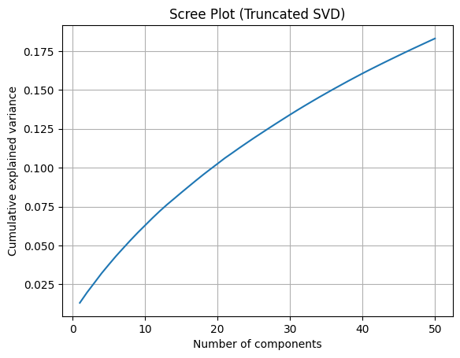

```python
svd = TruncatedSVD(n_components=50, random_state=42)
X_dummies_reduced = svd.fit_transform(X_sparse)

explained = np.cumsum(svd.explained_variance_ratio_)

plt.plot(range(1, len(explained)+1), explained)
plt.xlabel("Number of components")
plt.ylabel("Cumulative explained variance")
plt.title("Scree Plot (Truncated SVD)")
plt.grid(True)
plt.show()
```

200 components got us up to 40%, and 400 put us above 50%. At 1000 we got near 75% and felt that was sufficient.

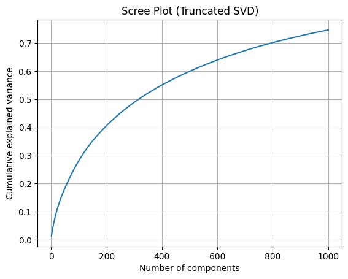

```python
svd = TruncatedSVD(n_components=1000, random_state=42)
X_dummies_reduced = svd.fit_transform(X_sparse)

explained = np.cumsum(svd.explained_variance_ratio_)

plt.plot(range(1, len(explained)+1), explained)
plt.xlabel("Number of components")
plt.ylabel("Cumulative explained variance")
plt.title("Scree Plot (Truncated SVD)")
plt.grid(True)
plt.show()
```

### Modeling

We started with an IsolationForest, which, loosely speaking, partitions the data by entropy or disorder, then identifies the points that split from the rest of the pack the fastest.

```python
# Combine reduced dummies + scaled numerics
X_final = np.hstack([X_num_scaled, X_dummies_reduced])

model = IsolationForest(n_estimators=100, contamination=0.05, n_jobs=-1, random_state=42)
model.fit(X_final)
```

```
IsolationForest(contamination=0.05, n_jobs=-1, random_state=42)
```

```python
df['anomaly'] = model.predict(X_final)
df['anomaly_label'] = df['anomaly'].map({1: 'normal', -1: 'anomaly'})
```

Before we talk about evaluating our models, we need to note something.

```python
df['anomaly_label'].value_counts(normalize=True)
```

```
anomaly_label
normal     0.950244
anomaly    0.049756
Name: proportion, dtype: float64
```

We predetermined how much of the data would be labeled anomalous when we first made the model, with a parameter called `contamination`. The model gives every point a score, and all this parameter does is decide where the line between the two categories is.

Since we have test data, we can set the `contamination` value to what we expect it to be. This isn't really data leakage because all it controls is the raw number of anomalous values. If our model is not very good, all an inflated `contamination` value will do is give us more wrong answers.

```python
df_te['Insp'].value_counts(normalize=True)
```

```
Insp
ok       0.922874
fraud    0.077126
Name: proportion, dtype: float64
```

Going forward, we will set `contamination` to 0.08, or 8%.

### Model evaluation

With unsupervised models, you need to ensure consistency. We ran the same Isolation Forest 5 times with 3 random seeds to make sure our results were reliable.

```python
def svd_run(X_sparse, X_num_scaled=X_num_scaled):
    svd = TruncatedSVD(n_components=1000, random_state=42)
    X_dummies_reduced = svd.fit_transform(X_sparse)
    X_final = np.hstack([X_num_scaled, X_dummies_reduced])
    return X_final

def i_forest(X_final, rando=100, n_estimators=100, contamination=0.08):
    model = IsolationForest(
        n_estimators=n_estimators,
        contamination=contamination,
        n_jobs=-1,
        random_state=rando)
    model.fit(X_final)
    return model
```

```python
seeds
```

```
[7, 7, 7, 7, 7, 19, 19, 19, 19, 19, 928, 928, 928, 928, 928]
```

```python
# 3x random seeds 5x runs each
seeds = [7]*5 + [19]*5 + [928]*5

runs = []

pbar = tqdm(enumerate(seeds))
for n, seed in pbar:
    pbar.set_description(f"Seed: {seed}, Run: {n}")
    X_out = i_forest(X_final, rando=seed)
    runs.append(X_out)
```

```
Seed: 928, Run: 14: : 15it [01:03,  4.21s/it]
```

Means are consistant across runs within random seeds. (First number in column header is seed.)

```python
test_runs = pd.DataFrame([r['scores'] for r in runs], index=[(7, 0), (7, 1), (7, 2), (7, 3), (7, 4),
 (19, 0), (19, 1), (19, 2), (19, 3), (19, 4),
 (928, 0), (928, 1), (928, 2), (928, 3), (928, 4)])
```

```python
test_runs.T.describe()
```

|  | (7, 0) | (7, 1) | (7, 2) | (7, 3) | (7, 4) | (19, 0) | (19, 1) | (19, 2) | (19, 3) | (19, 4) | (928, 0) | (928, 1) | (928, 2) | (928, 3) | (928, 4) |
| --- | --- | --- | --- | --- | --- | --- | --- | --- | --- | --- | --- | --- | --- | --- | --- |
| count | 129091.000000 | 129091.000000 | 129091.000000 | 129091.000000 | 129091.000000 | 129091.000000 | 129091.000000 | 129091.000000 | 129091.000000 | 129091.000000 | 129091.000000 | 129091.000000 | 129091.000000 | 129091.000000 | 129091.000000 |
| mean | 0.037313 | 0.037313 | 0.037313 | 0.037313 | 0.037313 | 0.040634 | 0.040634 | 0.040634 | 0.040634 | 0.040634 | 0.036899 | 0.036899 | 0.036899 | 0.036899 | 0.036899 |
| std | 0.020192 | 0.020192 | 0.020192 | 0.020192 | 0.020192 | 0.021166 | 0.021166 | 0.021166 | 0.021166 | 0.021166 | 0.019678 | 0.019678 | 0.019678 | 0.019678 | 0.019678 |
| min | -0.054805 | -0.054805 | -0.054805 | -0.054805 | -0.054805 | -0.068300 | -0.068300 | -0.068300 | -0.068300 | -0.068300 | -0.058247 | -0.058247 | -0.058247 | -0.058247 | -0.058247 |
| 25% | 0.024316 | 0.024316 | 0.024316 | 0.024316 | 0.024316 | 0.027410 | 0.027410 | 0.027410 | 0.027410 | 0.027410 | 0.024196 | 0.024196 | 0.024196 | 0.024196 | 0.024196 |
| 50% | 0.040841 | 0.040841 | 0.040841 | 0.040841 | 0.040841 | 0.045063 | 0.045063 | 0.045063 | 0.045063 | 0.045063 | 0.040043 | 0.040043 | 0.040043 | 0.040043 | 0.040043 |
| 75% | 0.053507 | 0.053507 | 0.053507 | 0.053507 | 0.053507 | 0.058060 | 0.058060 | 0.058060 | 0.058060 | 0.058060 | 0.052868 | 0.052868 | 0.052868 | 0.052868 | 0.052868 |
| max | 0.067325 | 0.067325 | 0.067325 | 0.067325 | 0.067325 | 0.070455 | 0.070455 | 0.070455 | 0.070455 | 0.070455 | 0.065366 | 0.065366 | 0.065366 | 0.065366 | 0.065366 |

## Big Modeling

Now we are ready to see how our model performs by training it, then running unseen data through it and seeing it we find the same anomalies. We will be using F1 score to evaluate the models.

We built a big class to make this easier.

```python
class AnomalyPipeline:
    def __init__(self, n_components=1000, n_estimators=100, contamination=0.08, random_state=42):
        self.n_components = n_components
        self.n_estimators = n_estimators
        self.contamination = contamination
        self.random_state = random_state

        self.scaler = None
        self.svd = None
        self.model = None
        self.num_cols = ['Quant', 'Val', 'Price_dev']
        self.extra_cols = ['Each', 'Avg_Each', 'Insp', 'anomaly', 'anomaly_label']
        self.dummy_columns = None  # Will be tracked to align test data

    def preprocess(self, df, drop_nulls=True, fit=True):
        df = df.copy()
        if drop_nulls:
            df = df.dropna()
        df['Each'] = df['Val'] / df['Quant']
        df['Avg_Each'] = df.groupby('Prod')['Each'].transform('mean')
        df['Price_dev'] = df['Each'] - df['Avg_Each']

        # Numeric features
        X_num = df[self.num_cols]
        if fit:
            self.scaler = StandardScaler()
            X_num_scaled = self.scaler.fit_transform(X_num)
        else:
            X_num_scaled = self.scaler.transform(X_num)

        # Categorical dummies
        df_dummies = pd.get_dummies(df.drop(columns=self.num_cols + self.extra_cols), drop_first=True)

        X_sparse = csr_matrix(df_dummies.values)

        return X_num_scaled, X_sparse

    def fit(self, df_train):
        X_num_scaled, X_sparse = self.preprocess(df_train, fit=True)

        self.svd = TruncatedSVD(n_components=self.n_components, random_state=self.random_state)
        X_dummies_reduced = self.svd.fit_transform(X_sparse)

        X_final = np.hstack([X_num_scaled, X_dummies_reduced])

        self.model = IsolationForest(
            n_estimators=self.n_estimators,
            contamination=self.contamination,
            n_jobs=-1,
            random_state=self.random_state
        )
        self.model.fit(X_final)
        return self

    def predict(self, df_test):
        X_num_scaled, X_sparse = self.preprocess(df_test, fit=False)
        X_dummies_reduced = self.svd.fit_transform(X_sparse)
        X_final = np.hstack([X_num_scaled, X_dummies_reduced])

        labels = self.model.predict(X_final)
        scores = self.model.decision_function(X_final)

        return labels, scores
```

```python
ap = AnomalyPipeline()
```

```python
df.select_dtypes("number")
```

|  | Quant | Val | Each | Avg_Each | Price_dev | anomaly |
| --- | --- | --- | --- | --- | --- | --- |
| 0 | 1032.0 | 4115.0 | 3.987403 | 5.487395 | -1.499991 | 1 |
| 1 | 718.0 | 4780.0 | 6.657382 | 5.487395 | 1.169987 | 1 |
| 2 | 585.0 | 3810.0 | 6.512821 | 5.487395 | 1.025426 | 1 |
| 3 | 904.0 | 7310.0 | 8.086283 | 5.487395 | 2.598889 | 1 |
| 4 | 6989.0 | 35850.0 | 5.129489 | 5.487395 | -0.357905 | 1 |
| ... | ... | ... | ... | ... | ... | ... |
| 133725 | 101.0 | 1035.0 | 10.247525 | 11.899603 | -1.652078 | 1 |
| 133726 | 381.0 | 4695.0 | 12.322835 | 11.899603 | 0.423232 | 1 |
| 133727 | 100.0 | 1080.0 | 10.800000 | 11.899603 | -1.099603 | 1 |
| 133729 | 103.0 | 1320.0 | 12.815534 | 11.899603 | 0.915931 | 1 |
| 133730 | 205.0 | 1615.0 | 7.878049 | 11.899603 | -4.021554 | 1 |

129091 rows × 6 columns

```python
ap.fit(df)
```

```
<__main__.AnomalyPipeline at 0x156d75150>
```

```python
# don't worry about it
for c in ['anomaly', 'anomaly_label']:
    df_te[c] = 0
```

```python
te_labels, te_scores = ap.predict(df_te)
```

```python
df_te['preds'] = te_labels
df_te['scores'] = te_scores
```

```python
df_te['preds'].replace(-1, 0, inplace=True)
```

```python
df_te[['preds', 'Insp']].value_counts()
```

```
preds  Insp
1      ok       13097
0      ok        1250
1      fraud     1089
0      fraud      110
Name: count, dtype: int64
```

```python
df_te['Insp'] = df_te['Insp'].map({"ok":1, "fraud": 0})
```

```python
f1_score(df_te['Insp'], df_te['preds'])
```

```
0.9180247432797112
```

91% is a very good score. But let's see how we do if we change the number of SVD components and number of Forest estimators.

```python
n_estimators = [100, 300, 1000]
n_comps = [200, 400, 800]

grid_ = list(product(n_comps, n_estimators))
```

```python
grid_results = []

pbar = tqdm(enumerate(grid_))
for i, (n_comp, n_est) in pbar:
    pbar.set_description(
        f"Components: {n_comp}, Estimators: {n_est}, Run {i+1} of {len(grid_)}"
        )

    ap = AnomalyPipeline(n_components=n_comp, n_estimators=n_est, random_state=None)

    ap.fit(df)
    te_labels, te_scores = ap.predict(df_te)
    output = dict(zip(
        ['n_est', 'n_comp', 'labels', 'scores'],
        [n_est, n_comp, te_labels, te_scores]
    ))
    grid_results.append(output)
```

```
Components: 800, Estimators: 1000, Run 9 of 9: : 9it [05:45, 38.34s/it]
```

```python
grid_results_1 = pd.DataFrame([{
    'estimators': r['n_est'],
    'components': r['n_comp'],
    'f1_score': f1_score(y_true, r['labels'])
} for r in grid_results])
```

```python
grid_results_1
```

|  | estimators | components | f1_score |
| --- | --- | --- | --- |
| 0 | 100 | 200 | 0.882861 |
| 1 | 300 | 200 | 0.889392 |
| 2 | 1000 | 200 | 0.894366 |
| 3 | 100 | 400 | 0.913292 |
| 4 | 300 | 400 | 0.888801 |
| 5 | 1000 | 400 | 0.897704 |
| 6 | 100 | 800 | 0.912916 |
| 7 | 300 | 800 | 0.902941 |
| 8 | 1000 | 800 | 0.905843 |

Not much improvement! Let's try some bigger values.

```python
n_estimators = [100, 300, 1000]
n_comps = [1000, 1500, 2000]

grid_ = list(product(n_comps, n_estimators))
```

```python
grid_results_2 = []

pbar = tqdm(enumerate(grid_))
for i, (n_comp, n_est) in pbar:
    pbar.set_description(
        f"Components: {n_comp}, Estimators: {n_est}, Run {i+1} of {len(grid_)}"
        )

    ap = AnomalyPipeline(n_components=n_comp, n_estimators=n_est, random_state=None)

    ap.fit(df)
    te_labels, te_scores = ap.predict(df_te)
    output = dict(zip(
        ['n_est', 'n_comp', 'labels', 'scores'],
        [n_est, n_comp, te_labels, te_scores]
    ))
    grid_results_2.append(output)
```

```
Components: 2000, Estimators: 1000, Run 9 of 9: : 9it [23:44, 158.24s/it]
```

```python
grid_results_2_df = pd.DataFrame([{
    'estimators': r['n_est'],
    'components': r['n_comp'],
    'f1_score': f1_score(y_true, r['labels'])
} for r in grid_results_2])
```

```python
grid_results_2_df
```

|  | estimators | components | f1_score |
| --- | --- | --- | --- |
| 0 | 100 | 1000 | 0.925459 |
| 1 | 300 | 1000 | 0.915164 |
| 2 | 1000 | 1000 | 0.913240 |
| 3 | 100 | 1500 | 0.924205 |
| 4 | 300 | 1500 | 0.916620 |
| 5 | 1000 | 1500 | 0.917280 |
| 6 | 100 | 2000 | 0.923012 |
| 7 | 300 | 2000 | 0.918447 |
| 8 | 1000 | 2000 | 0.922586 |

```python
grid_results_df = pd.concat([grid_results_1, grid_results_2_df])
```

Looks like we are topping out around 0.92, and we are most getting that extra value from increasing the number of components.

```python
grid_results_df
```

|  | estimators | components | f1_score |
| --- | --- | --- | --- |
| 0 | 100 | 200 | 0.882861 |
| 1 | 300 | 200 | 0.889392 |
| 2 | 1000 | 200 | 0.894366 |
| 3 | 100 | 400 | 0.913292 |
| 4 | 300 | 400 | 0.888801 |
| 5 | 1000 | 400 | 0.897704 |
| 6 | 100 | 800 | 0.912916 |
| 7 | 300 | 800 | 0.902941 |
| 8 | 1000 | 800 | 0.905843 |
| 0 | 100 | 1000 | 0.925459 |
| 1 | 300 | 1000 | 0.915164 |
| 2 | 1000 | 1000 | 0.913240 |
| 3 | 100 | 1500 | 0.924205 |
| 4 | 300 | 1500 | 0.916620 |
| 5 | 1000 | 1500 | 0.917280 |
| 6 | 100 | 2000 | 0.923012 |
| 7 | 300 | 2000 | 0.918447 |
| 8 | 1000 | 2000 | 0.922586 |